# Simulating clinical trials, various simulations

March 22, 2017

## Simulation before, during, and after a clinical trial: A Bayesian approach

## Introduction.

"A Bayesian is one who, vaguely expecting a horse, and catching a glimpse of a donkey, strongly believes he has seen a mule." –Stephen Senn

The fundamental approach in Bayesian data analysis is combining information from a prior distribution with information from the data. The posterior mean is a weighted average of the prior mean and the mean of the data. This is only true when you use an informative prior. When you use a non-informative prior (sometimes called a flat prior), the posterior mean is pretty much equal to the mean of the data.

The use of informative priors in testing efficacy and safety is controversial, but this should not stop you from using informative priors in monitoring the operational characteristics of a clinical trial.

## Part 1. An illustration of various simulations

Consider a clinical trial that plans to run for T = 1095 days (3 years). You hope to recruit N = 350 patients in that time, which would mean 0.32 patients per day or 9.6 patients per month. You suspect, however, that the accrual rate might actually be quite a bit higher or quite a bit lower than this target. You set a prior distribution on the accrual rate that is Gamma(140, 438). You need to wait for an explanation of why this might be a reasonable prior distribution. With this prior distribution, you can simulate many things.

## Figure 1.1. Simulation of a clinical trial with a fixed sample size.

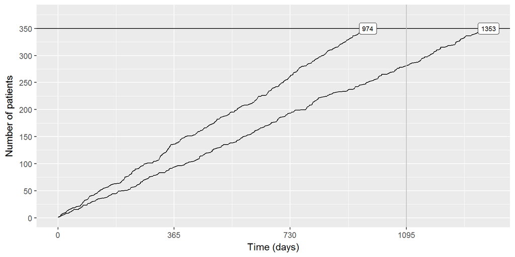

This is simulation of the amount of time it would take to recruit 350 patients. The target is 1095 days, but some simulations take less time and others take more time.

## Figure 1.2. Simulation of a clinical trial with a fixed time frame.

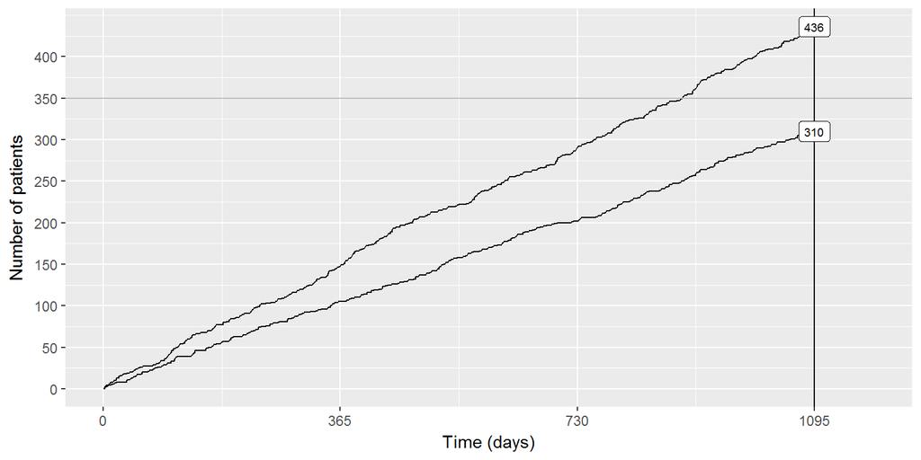

This is simulation of the number of patients you can recruit if you restrict the amount of time spentt to exactly 1095 days. The target is 350 patients, but some simulations estimate a larger or a smaller number of patients.

## Figure 1.3. Simulation of a trial with a conditional endpoint.

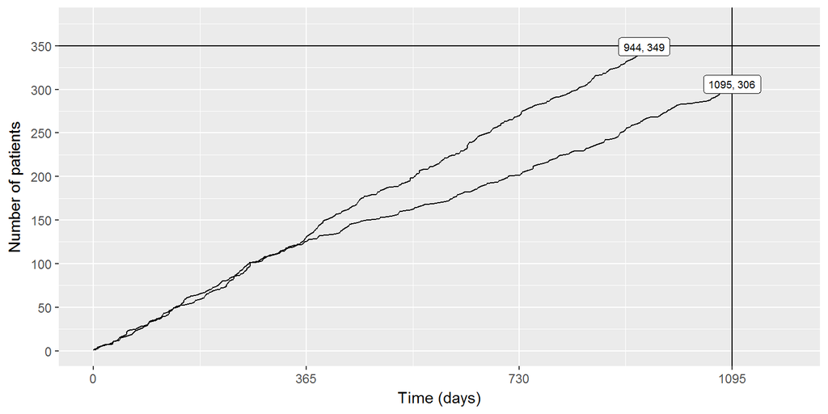

This is a trial with a conditional endpoint. You will end the trial when you get 350 patients or your trial takes 1095 days, whichever comes first.

## Figure 1.4. Simulation of the cost of a clinical trial.

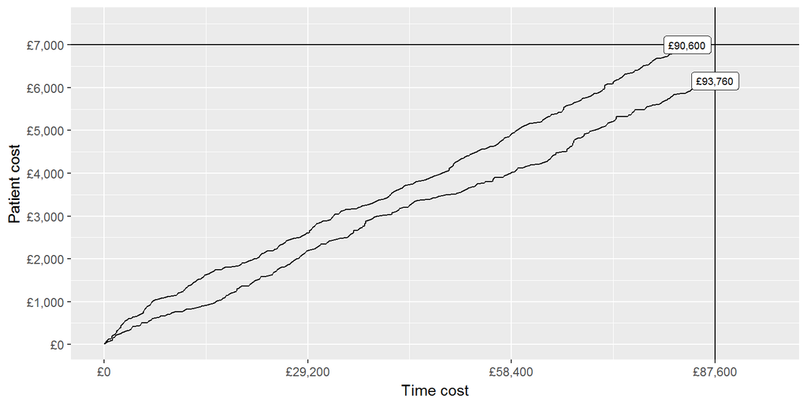

This is the same conditional endpoint, but you are measuring the cost of the trial rather than the number of patients or the amount of time. The cost is 80 British Pounds for each day of the trial and 20 British Poundns for each patient in the trial.